# Predicting Party Identification using Socioeconomic Characterisitcs

Author

D’Angelo Francis; Su Yeon Seo; Yuxiang Su

## Purpose

Our research project seeks to identify the key characteristics to identify and predict how a voter votes. This project utilizes random forests and bootstrap aggregation (bagged) trees model to predict the probability that a survey respondent’s political identification.

## Methodology

We trained our models not only for the United States, but for the Republic of Korea (“South Korea”), and the People’s Republic of China (‘mainland China’ or ‘China’) as well. The data for our US models is survey data from the American National Election Studies, or ANES, [Time Series Cumulative Data File 1948-2020](https://electionstudies.org/data-center/anes-time-series-cumulative-data-file/), a collaboration between Duke University,the University of Michigan,the University of Texas at Austin (UT Austin), Stanford University, and the National Science Foundation (NSF). For the KGSS model, we used survey data from the Inter-University Consortium for Political and Social Research (ICPSR) [Korean General Social Survey 2003-2021](https://www.icpsr.umich.edu/web/ICPSR/studies/38577)—or KGSS. For the Chinese model,we are using survey data from the [*Asian Barometer* Asian Democracy Survey](https://www.asianbarometer.org/datar?page=d10), an ongoing-research project of the Hu Fu Center for East Asia Democratic Studies at National Taiwan University (NTU).

For each model, we used questions that ask survey respondents about political leanings (e.g., *“Generally speaking, do you usually think of yourself as a Republican, a Democrat, an Independent, or what?”*) as the outcome variable our model will predict. The goal of the models are to *precisely* predict the political ID of survey respondents using responses from survey questions asking about politics, social sentiment, and demographic characteristics.

We use variable importance analysis to interpret the results from our tree models, and which survey questions and demographic characteristics are the best predictors of voters’ political ID.

**Using ‘Political ID’ versus ‘Vote’**

The original outcome variable for our models used questions that asked which party a survey respondent voted for. We decided *against* using such questions are variables since it is likely that a party’s candidate could influence who a survey respondent votes for *despite* political ID. We believe that political ID is a more reliable choice for our model to predict, though this does not rule out predicting voting behavior in the future.

## Building a U.S. Voter Political Identification Model

```r
set.seed(41224) # Euro style date for December 4,2024

# core packages

library(tidyverse)
library(tidymodels) # use case weights
library(readxl)
library(baguette)
library(vip)
library(pROC)
library(srvyr)
library(haven)
library(car) # for vif

# visualization packages

library(patchwork) # easy combine plots
library(ggthemes)

# Global Options

theme_set(theme_clean())
```

### ANES Survey Data

For the US model, we knew that it wouldn’t make sense to incorporate survey questions from over 70 years ago. Responses to questions about topics like LGBTQ rights, the Black Power movement, or the threat of communism would likely hurt the models predictive performance. We decided to narrow the scope of our models to the years 2000-2020 to take advantage of the significant, but relatively smaller political shift over the last 20 years rather than 76 years.

```r
# read data in - see README for link

anes_1948_2020 <-
  read_csv("data/anes_timeseries_cdf_csv_20220916.csv")

# tidying, getting years to 2000 - 2020 and pre-election vs post-election

anes_2000_2020 <-
  anes_1948_2020 |>
  select(
    # Year
    VCF0004,

    # Weight
    VCF9999, # post-election weight

    # Completion
    VCF0013, # post-election
    VCF0014, # pre-election
    VCF0748, # voted on election day or before

    # Dependent Variable(s)
    VCF0302, # initial party identification response
    VCF0303, # party identification response
    VCF0705, # vote for president - major parties and other

    # Demographic
    VCF0101, # age
    VCF0104, # gender
    VCF0105b, # race-ethnicity
    VCF0110, # education
    VCF0147, # marital status
    VCF0111, # urbanism (not available after 2000, drop or generated by spatial information)

    # Economic Condition
    VCF0114, # family-income
    VCF0116, # work status
    VCF0151, # occupation group (not available)
    VCF0146, # home ownership
    VCF9224, # stock market investment

    # Ideology
    VCF0128, # religion
    VCF0201:VCF0291, # attitude to different interest groups
    matches("^VCF08"), # policy preference
    matches("^VCF92"), # political opinion & VCF9277-82 personal info

    # Family Information
    VCF0306, # party identification of R's father
    VCF0307, # party identification of R's mother
    VCF0308, # political interest of R's father
    VCF0309, # political interest of R's mother
    VCF0138, # number of children in family


    # Spatial Information
    VCF0900, # congressional district of residence
    VCF0900b, # state and congressional district - fips
    VCF0900c, # state and congressional district - postal abbrev and cd
    VCF0901a, # state code - fips
    VCF0901b, # state postal abbrev
  ) |>
  filter(VCF0004 %in% c(2000:2020),
         VCF0014 == 1 & VCF0013 == 1,
         is.na(VCF9999) == FALSE,
         VCF0748 %in% c(1,5),
         VCF0705 > 0, # 0 - did not vote, declined to answer
         ) |>
  # transform missing value to NAs
  mutate(VCF0101 = ifelse(VCF0101 == 0, NA, VCF0101)) |>
  mutate(VCF0104 = ifelse(VCF0104 == 0, NA, VCF0104)) |>
  mutate(VCF0105b = ifelse(VCF0105b == 9, NA, VCF0105b)) |>
  mutate(VCF0110 = ifelse(VCF0110 == 0, NA, VCF0110)) |>
  mutate(VCF0147 = ifelse(VCF0147 %in% c(8,9), NA, VCF0147)) |>
  mutate(VCF0114 = ifelse(VCF0114 == 0, NA, VCF0114)) |>
  mutate(VCF0116 = ifelse(VCF0116 == 9, NA, VCF0116)) |>
  mutate(VCF0146 = ifelse(VCF0146 == 9, NA, VCF0146)) |> # high percentage of missing data
  mutate(VCF9224 = ifelse(VCF9224 %in% c(-8,-9), NA, VCF9224)) |>
  mutate(VCF0128 = ifelse(VCF0128 == 0, NA, VCF0128)) |>
  mutate(across(VCF0201:VCF0253, ~ ifelse(. %in% c(98, 99), NA, .))) |>
  mutate(VCF0290 = ifelse(VCF0290 %in% c(998, 999), NA, VCF0290)) |>
  mutate(VCF0291 = ifelse(VCF0291 %in% c(998, 999), NA, VCF0291)) |>
  mutate(VCF0801 = ifelse(VCF0801 %in% c(98, 99), NA, VCF0801)) |>
  mutate(VCF0803 = ifelse(VCF0803 %in% c(0, 9), NA, VCF0803)) |>
  mutate(VCF0804 = ifelse(VCF0804 %in% c(0, 9), NA, VCF0804)) |>
  mutate(across(VCF0806:VCF0823, ~ ifelse(. %in% c(0, 9), NA, .))) |>
  mutate(VCF0825 = ifelse(VCF0825 %in% c(0, 9), NA, VCF0825)) |>
  mutate(VCF0826 = ifelse(VCF0825 %in% c(0, 9), NA, VCF0825)) |>
  mutate(VCF0828 = ifelse(VCF0828 == 0, NA, VCF0828)) |>
  mutate(VCF0829 = ifelse(VCF0829 == 0, NA, VCF0829)) |>
  mutate(VCF0830 = ifelse(VCF0830 == 0, NA, VCF0830)) |>
  mutate(VCF0838 = ifelse(VCF0838 == 0, NA, VCF0838)) |>
  mutate(VCF0839 = ifelse(VCF0839 == 0, NA, VCF0839)) |>
  mutate(VCF0843 = ifelse(VCF0843 == 0, NA, VCF0843)) |>
  mutate(VCF0846 = ifelse(VCF0846 %in% c(0,8), NA, VCF0846)) |>
  mutate(VCF0849 = ifelse(VCF0849 %in% c(0,9), NA, VCF0849)) |>
  mutate(VCF0850 = ifelse(VCF0850 %in% c(0,9), NA, VCF0850)) |>
  mutate(VCF0852 = ifelse(VCF0852 == 9, NA, VCF0852)) |>
  mutate(VCF0853 = ifelse(VCF0853 == 9, NA, VCF0853)) |>
  mutate(VCF0867 = ifelse(VCF0867 == 9, NA, VCF0867)) |>
  mutate(VCF0870 = ifelse(VCF0870 %in% c(0,8), NA, VCF0870)) |>
  mutate(VCF0871 = ifelse(VCF0871 %in% c(0,8,9), NA, VCF0871)) |>
  mutate(VCF0872 = ifelse(VCF0872 %in% c(8,9), NA, VCF0872)) |>
  mutate(VCF0876 = ifelse(VCF0876 == 9, NA, VCF0876)) |>
  mutate(VCF0876a = ifelse(VCF0876a == 9, NA, VCF0876a)) |>
  mutate(VCF0878 = ifelse(VCF0878 == 9, NA, VCF0878)) |>
  mutate(VCF0879a = ifelse(VCF0879a == 9, NA, VCF0879a)) |>
  mutate(VCF0880 = ifelse(VCF0880 %in% c(0,9), NA, VCF0880)) |>
  mutate(VCF0880a = ifelse(VCF0880a %in% c(0,9), NA, VCF0880a)) |>
  mutate(VCF0881 = ifelse(VCF0881 %in% c(0,9), NA, VCF0881)) |>
  mutate(VCF0886 = ifelse(VCF0886 == 9, NA, VCF0886)) |>
  mutate(VCF0888 = ifelse(VCF0888 == 9, NA, VCF0888)) |>
  mutate(VCF0890 = ifelse(VCF0890 == 9, NA, VCF0890)) |>
  mutate(VCF0894 = ifelse(VCF0894 == 9, NA, VCF0894)) |>
  mutate(VCF0302 = ifelse(VCF0302 %in% c(8,9), NA, VCF0302))|>
  select(-where(~sum(is.na(.)) > 1000)) |>
  select(-c(VCF0004,VCF0901b, VCF0013,VCF0014, VCF0705, VCF0303,VCF0218,VCF0224,
            VCF0291,VCF0218,VCF0218,VCF0211,VCF0290,VCF0212, VCF0291))

anes_2000_2020$VCF0302 <- factor(anes_2000_2020$VCF0302)
```

### Model 1: Random Forests model with resampling

We used a random forests model with resampling to extract the most important survey question in determining a survey respondent’s political ID. Our outcome variable **VCF0302**—*Party Identification of Respondent*— had 39 missing observations. The nature of survey data suggests that this data may not be missing at random, so we ran the models with the missing observations and without the observations. Since there were no significant changes in the models, we dropped the missing observations in **VCF0302**. To deal with missing information in our predictor variables, we used `step_impute_bag()` to ‘fill in’ the missing information.

**Imputation Methods**

`tidyrecipes` provides multiple functions to ‘impute’ or fill in the missing value(s) of observations, usually labeled as `step_impute_<method>`. Functions such as `step_impute_mean()` and `step_impute_roll()` are computationally inexpensive. However, these functions are not fit for multinomial, or multi-class, predictive models.

We decided to use the algorithmic imputation function `step_impute_bagged()`, since it is better suited for multinomial predictive models compared to a linear imputation and *k*-nearest neighbor approach.

Since the number of variables made using a high number of trees *very* difficult with respect to code runtime, we settled on using `trees = 5` for all predictor imputations.

We acknowledge that our results may change should the number of trees be increased of imputations.

```r
# Only 39 obs missing in VCF0302 out of thousands; shouldn't impact result if dropped
anes_2000_2020 <-
  anes_2000_2020 |>
  mutate(VCF9999 = importance_weights(VCF9999)) |> # create recipe case weight
  filter(is.na(VCF0302) == FALSE)

anes_split <- initial_split(anes_2000_2020)

anes_train <- training(x = anes_split)

anes_test <- testing(x = anes_split)

anes_folds <- vfold_cv(data = anes_train, v = 5)

anes_recipe <-
  recipe(formula = VCF0302~ ., data = anes_train) |>
  step_impute_bag(all_predictors(), trees = 5)


anes_rf_mod <-
    rand_forest(
      trees = 500,
      mtry = 10,
      min_n = 4
    ) |>
  set_mode(mode = "classification") |>
  set_engine(
    engine = "ranger",
    importance = "impurity",
    num.threads = 4
  )

anes_rf_wf <-
  workflow() |>
  add_recipe(anes_recipe) |>
  add_model(anes_rf_mod) |>
  add_case_weights(VCF9999)

anes_rf_resamples <-
  anes_rf_wf |>
  fit_resamples(resamples = anes_folds)

collect_metrics(anes_rf_resamples) # dropping obs doesn't hurt metrics significantly
```

```
# A tibble: 3 × 6
  .metric     .estimator  mean     n  std_err .config
  <chr>       <chr>      <dbl> <int>    <dbl> <chr>
1 accuracy    multiclass 0.684     5 0.00243  Preprocessor1_Model1
2 brier_class multiclass 0.221     5 0.000891 Preprocessor1_Model1
3 roc_auc     hand_till  0.795     5 0.00403  Preprocessor1_Model1
```

**Accuracy vs. Brier vs. ROC-AUC**

Though all three metrics are helpful in determining model performance, all three are created differently:

**Accuracy**

How correct is the model overall?

**Brier Score**

This is the [mean square error](https://library.virginia.edu/data/articles/a-brief-on-brier-scores) with respect to forecasts. A value of 0 is excellent, and a value of 1 is poor *if* the model deals with a binary choice. If the number of possible categories exceeds 2, the multinomial Brier score is used which is a sum of the mean squared errors with a range of [0,2]. Higher numbers are still worse than lower numbers with the multinominal Brier score.

**ROC-AUC**

Stands for *R*eceiver-*o*perating *c*haracteristic_*A*rea *u*nder the *c*urve. This maps the true positive rate of our model. The closer the value is to 1, the better the model is at predicting events.

The accuracy of the random forest model is impressive—68.4 percent! Our ROC-AUC value is approximately .8, indicating a good model. However, our brier score is a decent .22.

```r
anes_rf_final <-
  anes_rf_wf |>
  last_fit(anes_split)

anes_rf_final |>
  collect_metrics()
```

```
# A tibble: 3 × 4
  .metric     .estimator .estimate .config
  <chr>       <chr>          <dbl> <chr>
1 accuracy    multiclass     0.694 Preprocessor1_Model1
2 roc_auc     hand_till      0.798 Preprocessor1_Model1
3 brier_class multiclass     0.221 Preprocessor1_Model1
```

Assessing out final fit metrics, our metrics still point to an excellent predictive model for *VCF0302* using random forests. Now, let’s look at which variables—or questions—are driving this model’s performance.

#### Random Forest variable importance

```r
anes_vip_plot <-
  anes_rf_final |>
  extract_fit_parsnip() |>
  vip(num_features = 20)
```

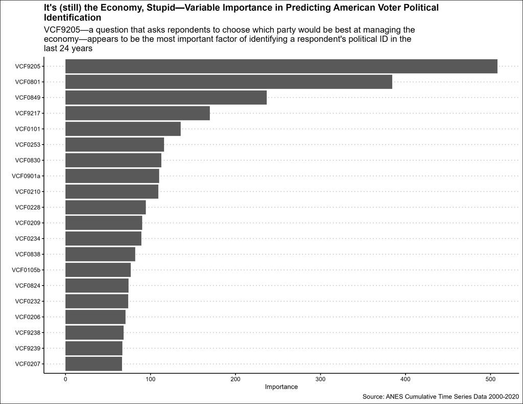

ANES Variable Importance

For our variable importance plot, we selected the top 20 variable that help our model’s accuracy. Leading by a wide margin is **VCF9205**—*Which party would do a better job handling the nation’s economy?*. Rounding out the top 5 are:

- **VCF0801**: *Thermometer index - Rating of liberals and conservatives*[^1]
- **VCF0849**: *Liberal-Conservative position 1984- Collapsed*[^2]
- **VCF9217**: *Does Respondent approve or disapprove of the way current U.S. President is handling foreign relations?*
- **VCF0101**: *Respondent’s Age*

We anticipate that question **VCF0838**-*By law, when should abortion be allowed?*— could be higher in variable importance once ANES releases a version including election data from 2022 and 2024. Both years had major impacts on voting trends political identification in the United States, as the United States Supreme Court under a 6-3 conservative majority voted to overturn *Roe v. Wade* in June 2022, which guaranteed the right to an abortion across the United States.[^3] The 2024 Presidential election featured Democratic campaigns attacking Republican candidates about Project 2025 and plans for a national abortion ban.[^4]

We also anticipate that question **VCF0867a**—*Affirmative Action in hiring/promotion*—may also increase in importance in future editions of the ANES survey given the Supreme Court also overturned precedent for affirmative action in the college application process in June 2023.[^5]

```r
lm_model <- lm(VCF9239 ~ VCF9205 + VCF0801 + VCF0849 + VCF9217 + VCF0101 + VCF0253 + VCF0830 + VCF0901a + VCF0210 + VCF0228 + VCF0209 + VCF0234 + VCF0838 + VCF0105b + VCF0824 + VCF0232 + VCF0232 + VCF0206 + VCF9238 + VCF0207, data = anes_train)

# calculate vif

vif_values <- vif(lm_model)

vif_values
```

```
 VCF9205  VCF0801  VCF0849  VCF9217  VCF0101  VCF0253  VCF0830 VCF0901a
1.620254 3.364884 2.543397 1.186504 1.123166 2.050936 1.566414 1.009015
 VCF0210  VCF0228  VCF0209  VCF0234  VCF0838 VCF0105b  VCF0824  VCF0232
1.415873 1.286784 1.343158 1.808025 1.281815 1.080300 1.299824 1.679081
 VCF0206  VCF9238  VCF0207
1.706573 1.263041 1.565518
```

The variance inflation factors (VIF) from this regression indicate that there is no multi-collinearity between VCF9239 and the other top 19 variables. Is this a case of overestimating the effect of gun control on voter political ID, specifically in the media?

Surprisingly, question **VCF0105b**—*Four category Race-Ethnicity Summary*, appears closer to the bottom. We are curious as to whether race is also overestimated as a key variable in a voter’s political identification. The rightward trend we saw in the 2024 Presidential election seems to suggests that race isn’t as big a divider as it appears, at least in the current political *zeitgeist*.[^6]

Now, we can test the model’s actual predictive performance for precision and recall.

```r
anes_rf_final_wf <-
  anes_rf_final |>
  extract_workflow()

anes_rf_predictions <-
  predict(anes_rf_final_wf, new_data = anes_test) |>
  bind_cols(
    predict(anes_rf_final_wf, new_data = anes_test, type = "prob"),
    anes_test |>
    select(VCF0302)
  )

select(anes_rf_predictions, VCF0302, starts_with(".pred"))
```

```
# A tibble: 2,436 × 7
   VCF0302 .pred_class .pred_1 .pred_2 .pred_3 .pred_4 .pred_5
   <fct>   <fct>         <dbl>   <dbl>   <dbl>   <dbl>   <dbl>
 1 2       1            0.605    0.272  0.039   0.0125  0.0718
 2 5       5            0.0268   0.309  0.011   0.0147  0.638
 3 2       5            0.272    0.286  0.065   0.0318  0.345
 4 5       5            0.148    0.278  0.0848  0.014   0.475
 5 5       5            0.0815   0.313  0.067   0.0225  0.516
 6 2       5            0.104    0.328  0.0627  0.0365  0.469
 7 5       5            0.171    0.270  0.037   0.016   0.507
 8 1       2            0.201    0.353  0.0758  0.0305  0.340
 9 5       5            0.128    0.325  0.0523  0.0345  0.460
10 3       5            0.109    0.260  0.0603  0.0118  0.560
# ℹ 2,426 more rows
```

**Interpreting model predictions**

- 1: *Republican*
- 2: *Independent*
- 3: *No preference;none;neither*
- 4: *Other*
- 5: *Democrat*

The value in **VCF0302** is the ‘true’ class, and the titular **.pred_class** is the predicted class given by the model.

```r
anes_rf_predictions |>
  precision(
    truth = VCF0302,
    estimate = .pred_class)
```

```
# A tibble: 1 × 3
  .metric   .estimator .estimate
  <chr>     <chr>          <dbl>
1 precision macro          0.664
```

```r
anes_rf_predictions |>
  recall(
    truth = VCF0302,
    estimate = .pred_class
  )
```

```
# A tibble: 1 × 3
  .metric .estimator .estimate
  <chr>   <chr>          <dbl>
1 recall  macro          0.417
```

```r
anes_rf_confmat <-
  conf_mat(data = anes_rf_predictions,
         truth = VCF0302,
         estimate = .pred_class)

anes_rf_confmat
```

```
          Truth
Prediction   1   2   3   4   5
         1 665 199   6  22  29
         2  61 209  16  14  79
         3   0   0   0   0   0
         4   0   0   0   0   0
         5  26 251  20  22 817
```

Our precision is approximately 66 percent using the [macro estimator](https://yardstick.tidymodels.org/articles/multiclass.html)—similar to our accuracy. Our recall rate, or ‘true positive rate’ (also using the macro estimator), is decent at approximately 42 percent.

The random forest model yields good predictions of voter political identification in the United States. This model is ready for implementation for amateur pollsters to Political Action Committee leadership. But, could we do better by using a bootstrap aggregation approach with hyper-parameter tuning?

### Model 2: Bagged Trees with Hyper-Parameter Tuning and Re-sampling

Now, we are building a bagged trees model using hyper-parameter tuning and re-sampling to compare which ‘tree’ model is the best.

```r
anes_bagged_trees_model <-
  bag_tree(cost_complexity = tune(), tree_depth = tune()) |>
  set_engine("rpart") |>
  set_mode("classification")

anes_bagged_folds <- vfold_cv(data = anes_train, v = 5)

anes_bagged_grid <- grid_regular(cost_complexity(),tree_depth(), levels = 3)

anes_bagged_trees_wf <-
  workflow() |>
  add_recipe(anes_recipe) |>
  add_model(spec = anes_bagged_trees_model) |>
  add_case_weights(VCF9999)

anes_bagged_trees_resamples <-
  anes_bagged_trees_wf |>
  tune_grid(
    resamples = anes_bagged_folds,
    grid = anes_bagged_grid
  )

collect_metrics(anes_bagged_trees_resamples)
```

```
# A tibble: 27 × 8
   cost_complexity tree_depth .metric     .estimator  mean     n std_err .config
             <dbl>      <int> <chr>       <chr>      <dbl> <int>   <dbl> <chr>
 1    0.0000000001          1 accuracy    multiclass 0.615     5 0.00771 Prepro…
 2    0.0000000001          1 brier_class multiclass 0.268     5 0.00448 Prepro…
 3    0.0000000001          1 roc_auc     hand_till  0.622     5 0.0122  Prepro…
 4    0.00000316            1 accuracy    multiclass 0.616     5 0.00923 Prepro…
 5    0.00000316            1 brier_class multiclass 0.267     5 0.00391 Prepro…
 6    0.00000316            1 roc_auc     hand_till  0.625     5 0.00721 Prepro…
 7    0.1                   1 accuracy    multiclass 0.615     5 0.00771 Prepro…
 8    0.1                   1 brier_class multiclass 0.266     5 0.00383 Prepro…
 9    0.1                   1 roc_auc     hand_till  0.641     5 0.00991 Prepro…
10    0.0000000001          8 accuracy    multiclass 0.667     5 0.00599 Prepro…
# ℹ 17 more rows
```

Since we are tuning the bagged trees model’s `tree_depth()` and `cost_complexity()`, we have multiple models to choose from. We can use `show_best()` and `select_best()` to isolate the model we want to use for predictions.

```r
anes_bagged_trees_resamples |>
  show_best(metric = "accuracy")
```

```
# A tibble: 5 × 8
  cost_complexity tree_depth .metric  .estimator  mean     n std_err .config
            <dbl>      <int> <chr>    <chr>      <dbl> <int>   <dbl> <chr>
1    0.00000316            8 accuracy multiclass 0.668     5 0.00335 Preprocess…
2    0.0000000001          8 accuracy multiclass 0.667     5 0.00599 Preprocess…
3    0.0000000001         15 accuracy multiclass 0.657     5 0.00315 Preprocess…
4    0.00000316           15 accuracy multiclass 0.653     5 0.00404 Preprocess…
5    0.00000316            1 accuracy multiclass 0.616     5 0.00923 Preprocess…
```

Using accuracy as the metric[^7], our fifth model where mean accuracy is approximately 67 percent, `tree_depth = 8`,and `cost_complexity = 0.00000316` is the best model. Now we can use `select_best()` to finalize our bagged trees model.

```r
best_bagged_value <-
  anes_bagged_trees_resamples |>
  select_best(metric = "accuracy")

anes_bagged_best_wf <-
  anes_bagged_trees_wf |>
  finalize_workflow(best_bagged_value)
```

Now, we run our bagged tree model with the best parameters given by hyperparameter tuning:

```r
anes_bagged_finalized_fit <-
  anes_bagged_best_wf |>
  last_fit(anes_split)

anes_bagged_fitted_wf <-
  anes_bagged_finalized_fit |>
  extract_workflow()

anes_bagged_predictions <-
  predict(anes_bagged_fitted_wf, new_data = anes_test) |>
  bind_cols(
    predict(anes_bagged_fitted_wf, new_data = anes_test, type = "prob"),
    anes_test |>
    select(VCF0302)
  )

select(anes_bagged_predictions, VCF0302, .pred_class, starts_with(".pred"))
```

```
# A tibble: 2,436 × 7
   VCF0302 .pred_class .pred_1 .pred_2 .pred_3  .pred_4 .pred_5
   <fct>   <fct>         <dbl>   <dbl>   <dbl>    <dbl>   <dbl>
 1 2       1            0.815    0.130 0.0139  0.00976   0.0313
 2 5       5            0.0216   0.264 0.0129  0.00660   0.695
 3 2       2            0.231    0.378 0.0629  0.0184    0.309
 4 5       5            0.250    0.328 0.0620  0.0182    0.341
 5 5       5            0.0680   0.286 0.00764 0.00560   0.633
 6 2       2            0.0321   0.429 0.112   0.0416    0.386
 7 5       5            0.0242   0.146 0.0196  0.00577   0.804
 8 1       2            0.243    0.365 0.0450  0.0292    0.318
 9 5       5            0.0389   0.431 0.0236  0.0598    0.447
10 3       2            0.242    0.389 0.268   0.000565  0.100
# ℹ 2,426 more rows
```

```r
anes_bagged_predictions |>
  precision(
    truth = VCF0302,
    estimate = .pred_class)
```

```
# A tibble: 1 × 3
  .metric   .estimator .estimate
  <chr>     <chr>          <dbl>
1 precision macro          0.483
```

```r
anes_bagged_predictions |>
  recall(
    truth = VCF0302,
    estimate = .pred_class
  )
```

```
# A tibble: 1 × 3
  .metric .estimator .estimate
  <chr>   <chr>          <dbl>
1 recall  macro          0.407
```

```r
anes_bagged_confmat <-
  conf_mat(data = anes_bagged_predictions,
         truth = VCF0302,
         estimate = .pred_class)

anes_bagged_confmat # values for markdown table
```

```
          Truth
Prediction   1   2   3   4   5
         1 639 194  11  22  28
         2  81 228  19  14 118
         3   0   2   0   0   1
         4   0   0   0   0   0
         5  32 235  12  22 778
```

The precision of this model after hyper-parameter tuning and re-sampling is approximately 48 percent. The recall rate is approximately 41 percent. I believe that we could get away with implementing this model in the American political arena.

### Bagged Trees vs Random Forests

Both models had reasonably high accuracy and recall rates. However, the random forest model is more precise than the bagged trees model. The precision of the random forest model is almost 20 percentage points higher than that of the bagged trees model. We believe this can be attributed to the nature of each model. Random forest models ‘de-correlate’ the trees and introduce some randomness Each tree is made worse off from before to improve the overall model fit. Bagged trees cannot do this since it uses bootstrapping to build its trees. Since the ANES survey is bound to have highly correlated covariates, it is no surprise the the random forest model outperformed the bagged trees model with respect to precision.

## Comparing Apple Pie to *Injeolmi*: Are American and South Korean Survey Respondents Comparable with Respect to Voter Political Identification?

Our random forests model did reasonably well in predicting the political ID of American survey respondents. But the United States does not have a monopoly on democracy. 2024 is known as the “Year of Elections, as more than 60 countries had elections.[^8] One of these countries is South Korea. We believe that South Korea and the United States have a comparable political climate. Not only has South Korea experienced an presidential election, it has also recently experienced an attempted coup by the sitting president, Yoon Suk Yeol[^9]. Do these political similarities stem from voters’ political identification stemming from the same category of variables as American voters?

### KGSS Survey Data

```r
load("data/38577-0001-Data.rda")

kgss <-
  da38577.0001

# Variable selection data cleaning for NA values

kgss_reduced <-
  kgss |>
  select(
    PARTYLR, FINALWT,SEX,AGE, MARITAL,EDUC,TECHHIGH,SPEDUC,PAEDUC,MAEDUC,
    RINCOME,OCC,SATFIN,FINALTER,STDLIVIN,
    WORRY316,HELPPARE,KIDNUM10,PARSOL,CLASS,HOUSTYPE,HOUSOWNS,BLOODTYP,FEAR,
    FAMILY,FRIENDS,LEISURE,MONEY,EDUCATN,HEALTH,RELIGION,GETAHEAD,
    CULTBIAS1:CULTBIAS12,DONN1:DONN8,INDDIFF,IDEALFAM,MARIGOLD,WOMENCHD,
    LOVCOHAB,WOMENROL,MARABORT,HLPECONO,CHDOBEYP,HUSBWIFE,MARFUTUR,CHDFUTUR,
    FEJOBAFF,MAPAID,ABCHOOSE,HAPMAR,INFORAID,AIDOLD,
    GENCONF1:GENCONF5,OLDWELF1:OLDWELF3,OLDCONT1:OLDCONT3,CONGOVT,NATVSBUS,CURGOV,
    NORTHPOL, DEMOATT1:DEMOATT4)

kgss_reduced <-
  kgss_reduced |>
  mutate(FINALWT = importance_weights(FINALWT),
         SEX = ifelse(SEX %in% c("-1","-8"), NA, SEX),
         AGE = ifelse(AGE %in% c("-1","-8"), NA, AGE),
         MARITAL = ifelse(MARITAL %in% c("-1","-8"), NA, MARITAL),
         EDUC = ifelse(EDUC %in% c("-1","-8"), NA, EDUC),
         TECHHIGH = ifelse(TECHHIGH %in% c("-1","-8"), NA, TECHHIGH),
         SPEDUC = ifelse(SPEDUC %in% c("-1","-8"),NA, SPEDUC),
         PAEDUC = ifelse(PAEDUC %in% c("-1","-8"), NA, PAEDUC),
         MAEDUC = ifelse(MAEDUC %in% c("-1","-8"), NA, MAEDUC),
         RINCOME = ifelse(RINCOME %in% c("-1","-8"), NA, RINCOME),
         OCC = ifelse(OCC %in% c("-1","-8"), NA, OCC),
         SATFIN = ifelse(SATFIN %in% c("-1","-8"), NA, SATFIN),
         FINALTER = ifelse(FINALTER %in% c("-1","-8"), NA, FINALTER),
         STDLIVIN = ifelse(STDLIVIN %in% c("-1","-8"), NA, STDLIVIN),
         WORRY316 = ifelse(WORRY316 %in% c("-1","-8"), NA, WORRY316),
         HELPPARE = ifelse(HELPPARE %in% c("-1","-8"), NA, HELPPARE),
         KIDNUM10 = ifelse(KIDNUM10 %in% c("-1","-8"), NA, KIDNUM10),
         PARSOL = ifelse(PARSOL %in% c("-1","-8"), NA, PARSOL),
         CLASS = ifelse(CLASS %in% c("-1","-8"), NA, CLASS),
         HOUSTYPE = ifelse(HOUSTYPE %in% c("-1","-8"), NA, HOUSTYPE),
         HOUSOWNS = ifelse(HOUSOWNS %in% c("-1","-8"), NA, HOUSOWNS),
         BLOODTYP = ifelse(BLOODTYP %in% c("-1","-8"), NA, BLOODTYP),
         FEAR = ifelse(FEAR %in% c("-1","-8"), NA, FEAR),
         FAMILY = ifelse(FAMILY %in% c("-1","-8"), NA, FAMILY),
         FRIENDS = ifelse(FRIENDS %in% c("-1","-8"), NA, FRIENDS),
         LEISURE = ifelse(LEISURE %in% c("-1","-8"), NA, LEISURE),
         MONEY = ifelse(MONEY %in% c("-1","-8"), NA, MONEY),
         EDUCATN = ifelse(EDUCATN %in% c("-1","-8"), NA, EDUCATN),
         HEALTH = ifelse(HEALTH %in% c("-1","-8"), NA, HEALTH),
         RELIGION = ifelse(RELIGION %in% c("-1","-8"), NA, RELIGION),
         GETAHEAD = ifelse(GETAHEAD %in% c("-1","-8"), NA, GETAHEAD),
         CULTBIAS1 = ifelse(CULTBIAS1 %in% c("-1","-8"), NA, CULTBIAS1),
         CULTBIAS2 = ifelse(CULTBIAS2 %in% c("-1","-8"), NA, CULTBIAS1),
         CULTBIAS3 = ifelse(CULTBIAS3 %in% c("-1","-8"), NA, CULTBIAS3),
         CULTBIAS4 = ifelse(CULTBIAS4 %in% c("-1","-8"), NA, CULTBIAS4),
         CULTBIAS5 = ifelse(CULTBIAS5 %in% c("-1","-8"), NA, CULTBIAS5),
         CULTBIAS6 = ifelse(CULTBIAS6 %in% c("-1","-8"), NA, CULTBIAS6),
         CULTBIAS7 = ifelse(CULTBIAS7 %in% c("-1","-8"), NA, CULTBIAS7),
         CULTBIAS8 = ifelse(CULTBIAS8 %in% c("-1","-8"), NA, CULTBIAS8),
         CULTBIAS9 = ifelse(CULTBIAS9 %in% c("-1","-8"), NA, CULTBIAS9),
         CULTBIAS10 = ifelse(CULTBIAS10 %in% c("-1","-8"), NA, CULTBIAS10),
         CULTBIAS11 = ifelse(CULTBIAS11 %in% c("-1","-8"), NA, CULTBIAS11),
         CULTBIAS12 = ifelse(CULTBIAS12 %in% c("-1","-8"), NA, CULTBIAS12),
         DONN1 = ifelse(DONN1 %in% c("-1","-8"), NA, DONN1),
         DONN2 = ifelse(DONN2 %in% c("-1","-8"), NA, DONN2),
         DONN3 = ifelse(DONN3 %in% c("-1","-8"), NA, DONN3),
         DONN4 = ifelse(DONN4 %in% c("-1","-8"), NA, DONN4),
         DONN5 = ifelse(DONN5 %in% c("-1","-8"), NA, DONN5),
         DONN6 = ifelse(DONN6 %in% c("-1","-8"), NA, DONN6),
         DONN7 = ifelse(DONN7 %in% c("-1","-8"), NA, DONN7),
         DONN8 = ifelse(DONN8 %in% c("-1","-8"), NA, DONN8),
         INDDIFF = ifelse(INDDIFF %in% c("-1","-8"), NA, INDDIFF),
         IDEALFAM = ifelse(IDEALFAM %in% c("-1","-8"), NA, IDEALFAM),
         MARIGOLD = ifelse(MARIGOLD %in% c("-1","-8"), NA, MARIGOLD),
         WOMENCHD = ifelse(WOMENCHD %in% c("-1","-8"), NA, WOMENCHD),
         LOVCOHAB = ifelse(LOVCOHAB %in% c("-1","-8"), NA, LOVCOHAB),
         WOMENROL = ifelse(WOMENROL %in% c("-1","-8"), NA, WOMENROL),
         MARABORT = ifelse(MARABORT %in% c("-1","-8"), NA, MARABORT),
         HLPECONO = ifelse(HLPECONO %in% c("-1","-8"), NA, HLPECONO),
         CHDOBEYP = ifelse(CHDOBEYP %in% c("-1","-8"), NA, CHDOBEYP),
         HUSBWIFE = ifelse(HUSBWIFE %in% c("-1","-8"), NA, HUSBWIFE),
         MARFUTUR = ifelse(MARFUTUR %in% c("-1","-8"), NA, MARFUTUR),
         CHDFUTUR = ifelse(CHDFUTUR %in% c("-1","-8"), NA, CHDFUTUR),
         FEJOBAFF = ifelse(FEJOBAFF %in% c("-1","-8"), NA, FEJOBAFF),
         MAPAID = ifelse(MAPAID  %in% c("-1","-8"), NA, MAPAID),
         ABCHOOSE = ifelse(ABCHOOSE %in% c("-1","-8"), NA, ABCHOOSE),
         HAPMAR = ifelse(HAPMAR %in% c("-1","-8"), NA, HAPMAR),
         INFORAID = ifelse(INFORAID %in% c("-1","-8"), NA, INFORAID),
         AIDOLD = ifelse(AIDOLD %in% c("-1","-8"), NA, AIDOLD),
         GENCONF1 = ifelse(GENCONF1 %in% c("-1","-8"), NA, GENCONF1),
         GENCONF2 = ifelse(GENCONF2 %in% c("-1","-8"), NA, GENCONF2),
         GENCONF3 = ifelse(GENCONF3 %in% c("-1","-8"), NA, GENCONF3),
         GENCONF4 = ifelse(GENCONF4 %in% c("-1","-8"), NA, GENCONF4),
         GENCONF5 = ifelse(GENCONF5 %in% c("-1","-8"), NA, GENCONF5),
         OLDWELF1 = ifelse(OLDWELF1 %in% c("-1","-8"), NA, OLDWELF1),
         OLDWELF2 = ifelse(OLDWELF2 %in% c("-1","-8"), NA, OLDWELF2),
         OLDWELF3 = ifelse(OLDWELF3 %in% c("-1","-8"), NA, OLDWELF3),
         OLDCONT1 = ifelse(OLDCONT1 %in% c("-1","-8"), NA, OLDCONT1),
         OLDCONT2 = ifelse(OLDCONT2 %in% c("-1","-8"), NA, OLDCONT2),
         OLDCONT3 = ifelse(OLDCONT3 %in% c("-1","-8"), NA, OLDCONT3),
         CONGOVT = ifelse(CONGOVT %in% c("-1","-8"), NA, CONGOVT),
         NATVSBUS = ifelse(NATVSBUS %in% c("-1","-8"), NA, NATVSBUS),
         CURGOV = ifelse(CURGOV %in% c("-1","-8"), NA, CURGOV),
         NORTHPOL = ifelse(NORTHPOL %in% c("-1","-8"), NA, NORTHPOL),
         DEMOATT1 = ifelse(DEMOATT1 %in% c("-1","-8"), NA, DEMOATT1),
         DEMOATT2 = ifelse(DEMOATT2 %in% c("-1","-8"), NA, DEMOATT2),
         DEMOATT3 = ifelse(DEMOATT3 %in% c("-1","-8"), NA, DEMOATT3),
         DEMOATT4 = ifelse(DEMOATT4 %in% c("-1","-8"), NA, DEMOATT4),
         PARTYLR = ifelse(PARTYLR %in% c("-1", "-8"), NA, PARTYLR),
         PARTYLR = factor(PARTYLR)
  )

# PARTYLR is outcome variable

kgss_split <-
  kgss_reduced |>
  initial_split(prop = .75)

kgss_train <- training(kgss_split)

kgss_test <- testing(kgss_split)

kgss_folds <- vfold_cv(data = kgss_train, v = 5)

kgss_recipe <-
  recipe(PARTYLR~., data = kgss_train) |>
  step_impute_bag(all_predictors(), trees = 5) # can't go more than 5 trees or else runtime issues

kgss_model <-
  rand_forest(
    trees = 500,
    mtry = 5,
    min_n = 4
  ) |>
  set_mode("classification") |>
  set_engine(
    engine = "ranger",
    importance = "impurity",
    num.threads = 4
  )

kgss_rf_wf <-
  workflow() |>
  add_recipe(kgss_recipe) |>
  add_model(kgss_model) |>
  add_case_weights(FINALWT)

kgss_resamples <-
  kgss_rf_wf |>
  fit_resamples(resamples = kgss_folds)

collect_metrics(kgss_resamples) # the model sucks....?
```

```
# A tibble: 3 × 6
  .metric     .estimator  mean     n  std_err .config
  <chr>       <chr>      <dbl> <int>    <dbl> <chr>
1 accuracy    multiclass 0.367     5 0.00325  Preprocessor1_Model1
2 brier_class multiclass 0.360     5 0.000518 Preprocessor1_Model1
3 roc_auc     hand_till  0.661     5 0.00217  Preprocessor1_Model1
```

Our random forest model for South Korean voter political identification does not perform as well as we thought. Its accuracy is approximately 37 percent, has a mediocre brier score of .36, and the ROC-AUC score leaves more to be desired. Let’s look into the top 20 variables that our Korean model considers most important to its function.

### KGSS Variable Importance

```r
kgss_rf_final <-
  kgss_rf_wf |>
  last_fit(kgss_split)

kgss_vip_plot <-
  kgss_rf_final |>
  extract_fit_parsnip() |>
  vip(num_features = 20)
```

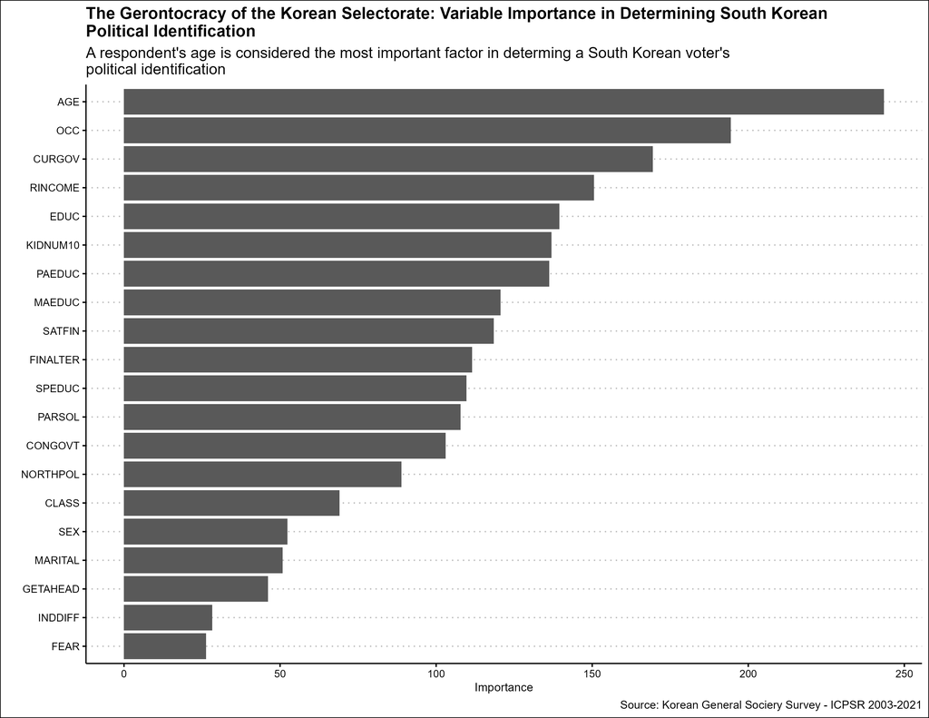

KGSS Variable Importance

The KGSS random forest model yields completely different results than the ANES model. The top 5 variables are:

- **AGE**-*Respondent’s age*
- **OCC**-*Respondent’s occupation*
- **CURGOV**-*Respondent’s assessment of current government’s state affair administrations*
- **RINCOME**-*Respondent’s income*
- **EDUC**: *Respondent’s educational attainment*

The ANES model also included questions about respondent’s age, education, occupation, and income. So, why does the ICPSR random forest model heavily use a respondent’s demographics rather than their political opinion? One reason can come from the survey composition itself. The ANES survey is a survey geared toward more political questions and is administered during presidential elections. The KGSS survey is a more general survey of South Korean society. This is one explanation we have for why the ANES models were great at predicting a respondent’s political ID compared to the KGSS.

### Testing KGSS predictive model

```r
kgss_final_wf <-
  kgss_rf_final |>
  extract_workflow()

kgss_rf_predictions <-
  predict(kgss_final_wf, new_data = kgss_test) |>
  bind_cols(
    predict(kgss_final_wf, new_data = kgss_test, type = "prob"),
    kgss_test |>
    select(PARTYLR)
  )

select(kgss_rf_predictions, PARTYLR, .pred_class, starts_with(".pred"))
```

```
# A tibble: 5,211 × 8
   PARTYLR .pred_class .pred_1 .pred_3 .pred_4 .pred_5 .pred_6 .pred_7
   <fct>   <fct>         <dbl>   <dbl>   <dbl>   <dbl>   <dbl>   <dbl>
 1 6       4            0.0469  0.0547  0.292    0.270   0.267  0.0687
 2 4       4            0.0369  0.0355  0.337    0.240   0.310  0.0410
 3 4       6            0.0371  0.0309  0.248    0.252   0.340  0.0914
 4 5       6            0.0913  0.0286  0.267    0.267   0.318  0.0276
 5 6       6            0.0479  0.0337  0.218    0.266   0.366  0.0686
 6 5       4            0.0250  0.0478  0.481    0.208   0.218  0.0199
 7 6       6            0.0749  0.0465  0.0921   0.261   0.425  0.100
 8 4       4            0.0349  0.0354  0.360    0.234   0.309  0.0273
 9 4       4            0.0306  0.101   0.342    0.254   0.247  0.0264
10 5       6            0.0346  0.0343  0.198    0.244   0.351  0.139
# ℹ 5,201 more rows
```

```r
kgss_rf_predictions |>
  precision(
    truth = PARTYLR,
    estimate = .pred_class)
```

```
# A tibble: 1 × 3
  .metric   .estimator .estimate
  <chr>     <chr>          <dbl>
1 precision macro          0.421
```

```r
kgss_rf_predictions |>
  recall(
    truth = PARTYLR,
    estimate = .pred_class
  )
```

```
# A tibble: 1 × 3
  .metric .estimator .estimate
  <chr>   <chr>          <dbl>
1 recall  macro          0.238
```

The precision of the KGSS model is approximately 42 percent. The recall of this model is around 24 percent. These values indicate that this model would *not* ready for practical implementation.

## Predicting Political Identification in One-Party Authoritarian Regimes - China

Surprisingly, our random forests model did not perform well in predicting the political identification of South Korean voters. Despite this, South Korean citizens have recently demonstrated their democratic resilience by successfully thwarting an attempted coup by the sitting president, Yoon Suk Yeol[^10], preventing a regression to authoritarian rule—a resilience rooted in their historical struggles against autocratic leaders. In stark contrast, mainland China has seen an erosion of the few remaining democratic norms. In 2018, President Xi Jinping abolished term limits in 2018’s constitutional amendment[^11]. Under Xi, China claims to have the ‘broadest, truest, and most effective democracy’ through its concept of ‘whole-process people’s democracy’[^12]. However, in recent years, China has become increasingly repressive as the CCP tightens control over all aspects of life and governance. In 2023, China was ranked as the third least electorally democratic country in the world. This raises a critical question: Do the determinants of political preferences in an entirely different political regime, align with those in democratic countries?

### Asian Barometer Survey Data

We use data from the Round 5 Asian Barometer Survey, conducted between 2018 and 2021, just after the constitutional amendment. From the original 306 variables, we select 156 variables that primarily cover information on thermometer ratings and demographics. Most of the dropped variables were excluded due to a high volume of missing data, likely resulting from censorship of speech. Our outcome variable is **q104**: *Where would you place our country [China] today? [Is] democracy suitable or not? [1:10][Democracy is completely unsuitable:Democracy is perfectly suitable]*

```r
china <- read_sav("data/w5_china.sav")

reduced_china <- china  |>
  select(matches("q"), SE4, SE5, SE5A, SE8A, SE8B, Se11, w, Political_affiliation) |>
  filter(q104 > -0 & q104 < 11) |>
  mutate(
    w = importance_weights(w),
    across(q1:q6, ~ ifelse(. %in% c(8, 9), NA, .)),
    across(q7:q17, ~ifelse(. %in% c(97, 98, 99), NA, .)),
    across(q22:q23, ~ ifelse(. %in% c(8, 9), NA, .)),
    across(q24:q27, ~ ifelse(. %in% c(97, 98, 99), NA, .)),
    across(q39:q48, ~ ifelse(. %in% c(8, 9), NA, .)),
    q49 = ifelse(q49 %in% c(97, 98, 99), NA, q49),
    q50 = ifelse(Q50 %in% c(8, 9), NA, Q50),
    q51a = ifelse(Q51A %in% c(7, 9), NA, Q51A),
    q51b = ifelse(Q51B %in% c(7, 9), NA, Q51B),
    q51c = ifelse(Q51C %in% c(7, 9), NA, Q51C),
    q51d = ifelse(Q51D %in% c(7, 9), NA, Q51D),
    q52 = ifelse(q52 %in% c(8, 9), NA, q52),
    across(q53:q55, ~ ifelse(. %in% c(97, 98, 99), NA, .)),
    across(q58:q90, ~ ifelse(. %in% c(-1, 0, 7, 8, 9), NA, .)),
    q82a = ifelse(q82a %in% c(8, 9), NA, q82a),
    q83a = ifelse(q83a %in% c(8, 9), NA, q83a),
    q84a = ifelse(q84a %in% c(8, 9), NA, q84a),
    q85a = ifelse(q85a %in% c(8, 9), NA, q85a),
    across(q91:q97, ~ ifelse(. %in% c(97, 98, 99), NA, .)),
    across(q98:q100, ~ ifelse(. %in% c(8, 9), NA, .)),
    across(q102:q104, ~ ifelse(. %in% c(97, 98, 99), NA, .)),
    q106 = ifelse(q106 %in% c(990, 998, 999), NA, q106),
    across(q107:q127, ~ ifelse(. %in% c(-1, 0, 7, 8, 9), NA, .)),
    across(q128:q131, ~ ifelse(. %in% c(97, 98, 99), NA, .)),
    across(q132:q173, ~ ifelse(. %in% c(97, 98, 99), NA, .)),
    q156_1 = ifelse(q156_1 %in% c(-1, 0, 7, 8, 9), NA, q156_1),
    q156a = ifelse(q156a %in% c(-1, 0, 7, 8, 9), NA, q156a),
    q157a = ifelse(q157a %in% c(-1, 0, 7, 8, 9), NA, q157a),
    q157_1 = ifelse(q157_1 %in% c(-1, 0, 7, 8, 9), NA, q157_1),
    q160a = ifelse(q160a %in% c(-1, 0, 7, 8, 9), NA, q160a),
    q160b = ifelse(q160b %in% c(-1, 0, 7, 8, 9), NA, q160b),
    q160c = ifelse(q160c %in% c(-1, 0, 7, 8, 9), NA, q160c),
    q160d = ifelse(q160d %in% c(-1, 0, 7, 8, 9), NA, q160d),
    q174 = ifelse(q174 %in% c(90, 97, 98, 99), NA, q174),
    q175 = ifelse(q175 %in% c(8, 9), NA, q175),
    q176 = ifelse(q176 %in% c(97, 98, 99), NA, q176),
    q177 = ifelse(q177 %in% c(8, 9), NA, q177),
    q178 = ifelse(q178 %in% c(-1, 97, 98, 99), NA, q178),
    q179 = ifelse(q179 %in% c(90, 97, 98, 99), NA, q179),
    q180 = ifelse(q180 %in% c(90, 97, 98, 99), NA, q180),
    across(q183:q185, ~ ifelse(. %in% c(8, 9), NA, .)),
    SE4 = ifelse(SE4 == 9, NA, SE4),
    SE5 = ifelse(SE5 == 99, NA, SE5),
    SE5A = ifelse(SE5A %in% c(90, 99), NA, SE5A),
    SE8A = ifelse(SE8A == 99, NA, SE8A),
    SE8B = ifelse(SE8B == 9, NA, SE8B),
    Se11 = ifelse(Se11 == 9999, NA, Se11),
  ) |>
  select(-where(~sum(is.na(.)) > 400)) |>
  mutate(q104 = as.factor(q104)) |>
  mutate(across(where(is.labelled), ~ as.numeric(.)))

reduced_china <- reduced_china |>
  select(-q18, , -q19, -q20, -q21, -(q28:q38), -q56, -q57, -q101, -q105, -q181, -q182)

# q104 is outcome variable

china_split <-
  reduced_china |>
  initial_split(prop = .75)

china_train <- training(china_split)

# discards the label to prevent errors in step_impute_bag()
china_train <- china_train |>
mutate(across(where(is.labelled), ~ zap_labels(.)))

china_test <- testing(china_split)

china_folds <- vfold_cv(data = china_train, v = 5)

china_recipe <-
  recipe(q104 ~ ., data = china_train) |>
  step_impute_bag(all_predictors(), trees = 5)

china_model <-
  rand_forest(
    trees = 500,
    mtry = 5,
    min_n = 4
  ) |>
  set_mode("classification") |>
  set_engine(
    engine = "ranger",
    importance = "impurity",
    num.threads = 4
  )

china_rf_wf <-
  workflow() |>
  add_recipe(china_recipe) |>
  add_model(china_model) |>
  add_case_weights(w)

china_resamples <-
  china_rf_wf |>
  fit_resamples(resamples = china_folds)

collect_metrics(china_resamples)
```

```
# A tibble: 3 × 6
  .metric     .estimator  mean     n std_err .config
  <chr>       <chr>      <dbl> <int>   <dbl> <chr>
1 accuracy    multiclass 0.369     5 0.00529 Preprocessor1_Model1
2 brier_class multiclass 0.376     5 0.00138 Preprocessor1_Model1
3 roc_auc     hand_till  0.755     5 0.0113  Preprocessor1_Model1
```

The metric of this model are similar to the KGSS model. The ROC-AUC is much higher and seems to suggest our model is better than what the accuracy and brier score are indicating. Let’s check the variable importance plot:

### China’s Variable Importance Graph

```r
china_rf_final <-
  china_rf_wf |>
  last_fit(china_split)

china_vip_plot <-
  china_rf_final |>
  extract_fit_parsnip() |>
  vip(num_features = 20)
```

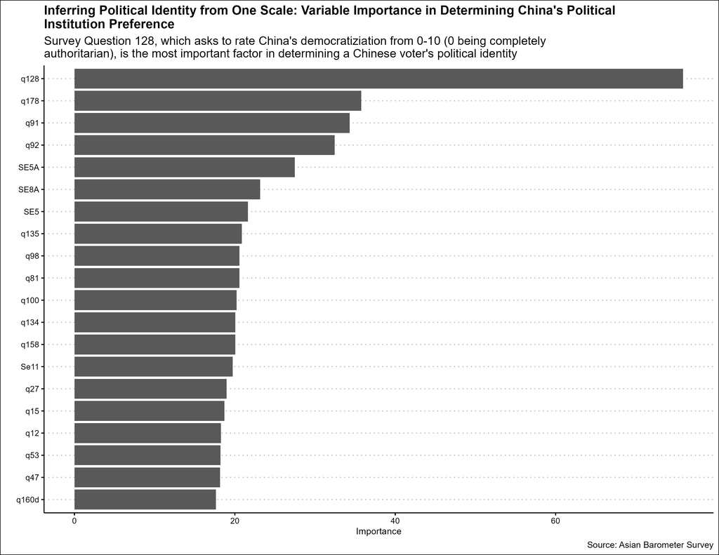

Chinese Survey Respondent Variable Importance

The top five variables are:

It makes sense that **q128** would be the most important variable by a long shot. If you are a respondent who believes China under the Chinese Communist Party is a strongly authoritarian regime, you may believe that building democratic institutions is not feasible. This also ties into **q91** and **q92**, as both are questions that gauge the health of the institutions that support democracy.

### Testing the China Predictive Model

```r
china_final_wf <-
  china_rf_final |>
  extract_workflow()

china_rf_predictions <-
  predict(china_final_wf, new_data = china_test) |>
  bind_cols(
    predict(china_final_wf, new_data = china_test, type = "prob"),
    china_test |>
    select(q104)
  )

select(china_rf_predictions, q104, .pred_class, starts_with(".pred"))
```

```
# A tibble: 997 × 12
   q104  .pred_class .pred_1  .pred_2 .pred_3 .pred_4 .pred_5 .pred_6 .pred_7
   <fct> <fct>         <dbl>    <dbl>   <dbl>   <dbl>   <dbl>   <dbl>   <dbl>
 1 10    8           0.00683 0         0.0135  0.0257  0.0597  0.101    0.139
 2 10    8           0.0112  0.00583   0.0127  0.013   0.0775  0.0988   0.186
 3 5     5           0.0065  0.0133    0.0352  0.0507  0.263   0.206    0.184
 4 9     8           0.0036  0.000286  0.005   0.0185  0.0558  0.0965   0.199
 5 8     8           0.00367 0.001     0.0055  0.001   0.0485  0.0707   0.149
 6 8     6           0.011   0.00367   0.033   0.0327  0.143   0.238    0.193
 7 9     7           0.004   0.0025    0.0248  0.0467  0.187   0.166    0.204
 8 6     8           0.00667 0.00117   0.027   0.055   0.144   0.206    0.193
 9 5     5           0.00817 0.0135    0.03    0.118   0.31    0.201    0.192
10 7     5           0.00317 0.00583   0.041   0.103   0.279   0.225    0.168
# ℹ 987 more rows
# ℹ 3 more variables: .pred_8 <dbl>, .pred_9 <dbl>, .pred_10 <dbl>
```

```r
china_rf_predictions |>
  precision(
    truth = q104,
    estimate = .pred_class)
```

```
# A tibble: 1 × 3
  .metric   .estimator .estimate
  <chr>     <chr>          <dbl>
1 precision macro          0.390
```

```r
china_rf_predictions |>
  recall(
    truth = q104,
    estimate = .pred_class
  )
```

```
# A tibble: 1 × 3
  .metric .estimator .estimate
  <chr>   <chr>          <dbl>
1 recall  macro          0.184
```

## Conclusion

Though only the United States has a model good enough for the ‘real world’, we still uncovered a wealth of knowledge about the South Korean selectorate and Chinese ‘quasi’-selectorate. We learned that the United States’ capitalistic attitudes is a primarily shapes a voter’s politics. In South Korea, voter characteristics—mainly age—shape voter preferences. In China, faith in democracy is pragmatic; shaped by how a respondent thinks about the current state of democracy in China.

## Notes

For the ANES model, we dropped variables where there were over one thousand NAs. This is because without dropping these variables, the model had ~230 variables with the class `logical`. A limitation of `tidyrecipes` is that there isn’t a function like `step_num2factor()` to assist in converting logical columns to a type that is easily imputed.

## Footnotes

[^1]: A survey ‘thermometer’ is a scale (0-100) which respondents are asked how warmly or coldly they perceive the subject of the thermometer question. Responses between 0-96 degrees were coded ‘as-is’ and responses between 97-100 degrees were coded as being 97-100 degrees (binned).
[^2]: To clarify, this question was asked from 1984 *and onward*, not only in the 1984 survey.
[^3]: [Roe v. Wade, Center for Reproductive Rights June 2022](https://reproductiverights.org/roe-v-wade/#:~:text=In%20June%202022%2C%20in%20a,federal%20constitutional%20right%20to%20abortion.)
[^4]: Sherman, C., [Project 2025: What does the rightwing blueprint say about abortion?](https://www.theguardian.com/us-news/article/2024/aug/05/project-2025-abortion), 5 August 2024
[^5]: Totenberg, N., [Supreme Court guts affirmative action, effectively ending race-conscious admissions](https://www.npr.org/2023/06/29/1181138066/affirmative-action-supreme-court-decision)
[^6]: Sides, J., [How to think about the “racial realignment” in U.S. politics](https://goodauthority.org/news/election-2024-racial-realignment-us-politics/), 18 November 2024
[^7]: The reason why we are using accuracy as a metric and not ROC-AUC is because of the estimator used. When we use accuracy, `yardstick` uses a ‘multi-class’ estimator since it detects that the outcome variable is a survey response with multiple answers, each coded as factors. When we use ROC-AUC, `yardstick` uses the ‘hand_till’ estimator, which does not work well with case weights.
[^8]: Wike, R.,Fagan,M.,Clancy,L.; [Global Elections in 2024: What We Learned in a Year of Political Disruption](https://www.pewresearch.org/global/2024/12/11/global-elections-in-2024-what-we-learned-in-a-year-of-political-disruption/), 11 December 2024
[^9]: Hyung-Jin Kim; Kim Tong-Hyung; [South Korea’s parliament votes to impeach President Yoon Suk Yeol over his martial law order](https://apnews.com/article/south-korea-martial-law-yoon-impeach-6432768aafc8b55be26215667e3c19d0), 14 December 2024
[^10]: Hyung-Jin Kim; Kim Tong-Hyung; [South Korea’s parliament votes to impeach President Yoon Suk Yeol over his martial law order](https://apnews.com/article/south-korea-martial-law-yoon-impeach-6432768aafc8b55be26215667e3c19d0), 14 December 2024
[^11]: Ng, K., Kwon, J., Ku, Yuna.; [South Korea opposition files motion to impeach President Yoon](https://www.bbc.com/news/articles/c8rjd064012o), 4 December 2024
[^12]: Doubek, J.; [China Removes Presidential Term Limits, Enabling Xi Jinping To Rule Indefinitely](https://www.npr.org/sections/thetwo-way/2018/03/11/592694991/china-removes-presidential-term-limits-enabling-xi-jinping-to-rule-indefinitely), 11 March 2018